# Midterm Assignment, ME314 2019

[figure not shown]

#### Summer School 2019 midsession examination

# ME314 Introduction to Data Science and Machine Learning

## Suitable for all candidates

### Instructions to candidates

- Complete the assignment by adding your answers directly to the RMarkdown document, knitting the document, and submitting the HTML file to Moodle.
- Time allowed: due 19:00 on Wednesday, 7th August 2019.
- Submit the assignment via [Moodle](https://shortcourses.lse.ac.uk/course/view.php?id=158).

## Question 1:

This question should be answered using the `Carseats` data set, which is part of the **ISLR** package. This data contains simulated data set containing sales of child car seats at 400 different stores.

```r
#Dataset
library(ISLR)
data("Carseats", package = "ISLR")
```

1. Fit a regression model predicting Sales using Advertising and Price as predictors. Interpret the coefficients, the $R^2$, and the Residual standard error from the regression (by explaining each in a few statements).

```r
#Regression Model
fit <- lm(Sales ~ Advertising + Price, data=Carseats)
summary(fit)
```

```
##
## Call:
## lm(formula = Sales ~ Advertising + Price, data = Carseats)
##
## Residuals:
##     Min      1Q  Median      3Q     Max
## -7.9011 -1.5470 -0.0223  1.5361  6.3748
##
## Coefficients:
##              Estimate Std. Error t value Pr(>|t|)
## (Intercept) 13.003427   0.606850  21.428  < 2e-16 ***
## Advertising  0.123107   0.018079   6.809 3.64e-11 ***
## Price       -0.054613   0.005078 -10.755  < 2e-16 ***
## ---
## Signif. codes:  0 '***' 0.001 '**' 0.01 '*' 0.05 '.' 0.1 ' ' 1
##
## Residual standard error: 2.399 on 397 degrees of freedom
## Multiple R-squared:  0.2819, Adjusted R-squared:  0.2782
## F-statistic: 77.91 on 2 and 397 DF,  p-value: < 2.2e-16
```

**The multiple linear equation formed is $Sales = 13.003427 + 0.123107 * Advertising - 0.054613 * Price$**

**All coefficients have p-values less than 0.05, indicating that all the regressors fitted are significant to the model at 5% level of significance.**

**Intercept has no physical intepretation as it represents the sales when both advertising and price is 0; while for coefficients, it represents the expected change in the response per unit change in the particular regressor when all of the remaining regressor variables are held constant. For instance, all else being equal, as advertising increases by 1 unit, sales increases by 0.123107 unit; also, all else being equal, as price increases by 1 unit, sales decreases by 0.054613 unit.**

**The adjusted R-squared value is 0.2782, indicating that 27.82% of variability of sales is explained by the model. The low adjusted R-squared value indicate that low variability of sales is explained by the model, thus this model may not be an appropriate model.**

**For a good model, we would prefer the residual standard error to be as close to 0 as possible. In this model, the residual standard error is 2.399, which is considered a large value, which indicates that this might not be a good model for this dataset.**

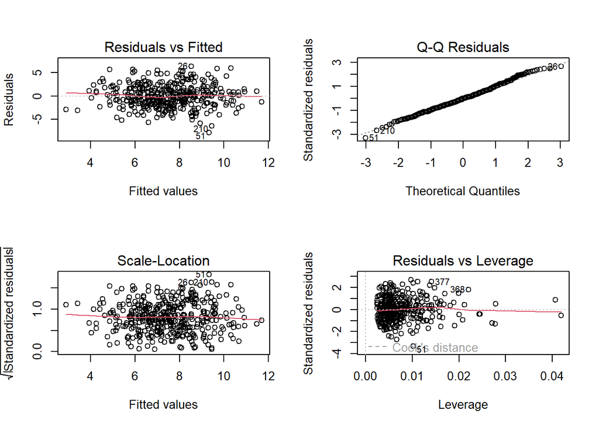

```r
#Residual Plot
par(mfrow = c(2, 2))
plot(fit)
```

**The first graph displays a rather straight line with slight deviation, indicating that the relationship between response and regressors are somewhat linear.**

**From the second graph, all the points are located on, or close to the straight line, indicating the data is normally distributed.**

**From the third graph, all points are randomly scattered with no obvious pattern observed, indicating that the variance is constant.**

**From the fourth graph, most data are clustered with a few data points located far from the cluster, indicating potential leverage point. However, all data are located within the Cook’s distance, which indicates the absence of influential point.**

2. Fit a second model by adding Urban as an interactive variable with Advertising. Interpret the two new coefficients produced by adding this interaction to the Advertising variable that was already present from the first question, in a few statements.

```r
#Second Regression Model with Interaction Effect
fit1 <- lm(Sales ~ Advertising * Urban + Price, data=Carseats)
summary(fit1)
```

```
##
## Call:
## lm(formula = Sales ~ Advertising * Urban + Price, data = Carseats)
##
## Residuals:
##     Min      1Q  Median      3Q     Max
## -7.8696 -1.5640 -0.0284  1.5323  6.3818
##
## Coefficients:
##                       Estimate Std. Error t value Pr(>|t|)
## (Intercept)          12.988703   0.666534  19.487  < 2e-16 ***
## Advertising           0.128015   0.034404   3.721 0.000227 ***
## UrbanYes              0.004602   0.369040   0.012 0.990057
## Price                -0.054519   0.005110 -10.670  < 2e-16 ***
## Advertising:UrbanYes -0.006666   0.040564  -0.164 0.869559
## ---
## Signif. codes:  0 '***' 0.001 '**' 0.01 '*' 0.05 '.' 0.1 ' ' 1
##
## Residual standard error: 2.405 on 395 degrees of freedom
## Multiple R-squared:  0.2819, Adjusted R-squared:  0.2747
## F-statistic: 38.77 on 4 and 395 DF,  p-value: < 2.2e-16
```

**The multiple linear equation formed is $Sales = 12.988703 + 0.128015 * Advertising - 0.054519 * Price + 0.004602 * Urban - 0.006666 * Advertising * Urban$, with Urban = 1 if the store is located in Urban area, and Urban = 0 otherwise.**

**Coefficients of Advertising and Price have p-values less than 0.05, indicating that both of these regressors are significant to the model at 5% level of significance. However, Urban has p-value of 0.990057, and the interaction between Advertising and Urban has a p-value of 0.869559, both greater than 0.05, indicating that both of these regressors are not significant to the model at 5% level of significance.**

**Advertising: Coefficient of 0.128015 suggests that, while all other regressors remain constant, an increase in advertising by 1 unit would increase the sales by 0.128015 unit.**

**Price: Coefficient of -0.054519 suggests that, while all other regressors remain constant, an increase in price by 1 unit would decrease the sales by 0.054519 unit.**

**UrbanYes: The coefficient does not suggest a relationship between sales and the location of store.**

**Advertising:UrbanYes: The coefficient does not provide an evidence for potential interaction between advertising and the location of the store, and also does not suggest a relationship between the interaction and sales.**

**The adjusted R-squared value is 0.2747, indicating that 27.47% of variability of sales is explained by the model. This value is lower than the previous model, suggesting that this model may not be an appropriate model.**

**For a good model, we would prefer the residual standard error to be as close to 0 as possible. In this model, the residual standard error is 2.405, which is considered a large value, which indicates that this might not be a good model for this dataset.**

3. Which of these two models is preferable, and why?

**By comparison, the first model has a higher adjusted R-squared value of 0.2782 compare to the second model with adjusted R-squared value of 0.2747, which indicates that the first model is actually preferable. This claim is supported by the lower Residual standard error of the first model compare to the second model.**